# Análise principal — Seazone Jovens Talentos 2026

## Ranking de investimento em short-stay — Itapema (SC)

Fluxo linear: preparação → Cap Rate (métrica A) → sensibilidade de ocupação → ocupação diferencial por bairro → eficiência por m² (métrica C) → ranking com coluna de confiança → deep-dive → cartão do investimento → mapas → considerações finais.

Decisões metodológicas consolidadas em `docs/metodologia.md`. Arquivos brutos em `data/` (imutáveis).

## 0. Importações e helpers

- normalização de bairro (mapa humano em `docs/metodologia.md`)
- bin de tipologia (apartamentos): 1qto (0-1), 2q, 3q, 4q+
- corte de outliers por quantil (1-99%)

## 1. Preparação — lado Airbnb (receita)

Junta `Details` (tipologia) + `Mesh` (bairro) + `Price_AV` (R$/noite). Exclui: `none`, `hotel`, `terreno`, `comercial`, `outros`, `casas`. Tipologia binada como `1qto/2q/3q/4q+`.

```
listings Airbnb (apartamento, com preço): 911
Amostra dos dados carregados (5 primeiros registros):
```

| Bairro | Tipologia | R$/noite |
| --- | --- | --- |
| meia praia | 3q | R$ 471 |
| meia praia | 3q | R$ 673 |
| meia praia | 3q | R$ 572 |
| meia praia | 3q | R$ 743 |
| meia praia | 3q | R$ 680 |

## 2. Preparação — lado VivaReal (preço de compra)

Filtra `apartamento`, `sale_price` > 0, outlier 1-99%, tipologia binada.

```
anúncios VivaReal (apartamento): 7297
Amostra dos dados carregados (5 primeiros registros):
```

| Bairro | Tipologia | Preço de compra | Área m² |
| --- | --- | --- | --- |
| meia praia | 3q | R$ 1,598,122 | 131 m² |
| meia praia | 3q | R$ 1,450,000 | 118 m² |
| castelo branco | 3q | R$ 1,500,000 | 125 m² |
| morretes | 2q | R$ 870,000 | 70 m² |
| andorinha | 3q | R$ 2,150,000 | 130 m² |

## 3. Tabela cruzada bairro × tipo

Agrega por célula: nº de listings Airbnb, nº de anúncios de venda, mediana R$/noite, mediana de preço de compra. Aplica corte de volume **N≥20 (Airbnb) e M≥15 (VivaReal)** por célula.

**Advertência**: a janela jan–abr (verão) superestima receita anualizada. O resultado é apresentado como **Cap Rate de pico/verão**, não média anual.

| Bairro | Tipo | Qtd Airbnb | Qtd venda | R$/noite | Preço compra | Área m² |
| --- | --- | --- | --- | --- | --- | --- |
| centro | 1qto | 78 | 18.000000 | R$ 471 | R$ 895.000 | 53.000000 |
| centro | 2q | 65 | 89.000000 | R$ 611 | R$ 1.150.000 | 86.000000 |
| centro | 3q | 45 | 438.000000 | R$ 749 | R$ 2.100.000 | 131.000000 |
| meia praia | 1qto | 28 | 58.000000 | R$ 495 | R$ 877.500 | 40.000000 |
| meia praia | 2q | 187 | 244.000000 | R$ 500 | R$ 1.075.000 | 85.000000 |
| meia praia | 3q | 327 | 1704.000000 | R$ 712 | R$ 1.884.860 | 129.000000 |
| meia praia | 4q+ | 65 | 1375.000000 | R$ 1.300 | R$ 3.671.338 | 188.000000 |
| morretes | 2q | 51 | 1010.000000 | R$ 500 | R$ 793.950 | 69.000000 |

## 4. Cap Rate short-stay (métrica A)

`cap_rate(ocupação) = ocupação × R$/noite × 365 ÷ preço de compra`

Como a ocupação real não está nos dados, apresentamos o multiplicador `k = R$/noite × 365 ÷ preço` e o Cap Rate para ocupações de cenário. **O ranking por `k` independe da ocupação** (ocupação só escalona os valores, não reordena).

| # | Bairro | Tipo | R$/noite | Preço compra | Cap 50% | Cap 60% | Cap 70% |
| --- | --- | --- | --- | --- | --- | --- | --- |
| 1 | morretes | 2q | R$ 500 | R$ 793.950 | 11,5% | 13,8% | 16,1% |
| 2 | meia praia | 1qto | R$ 495 | R$ 877.500 | 10,3% | 12,4% | 14,4% |
| 3 | centro | 2q | R$ 611 | R$ 1.150.000 | 9,7% | 11,6% | 13,6% |
| 4 | centro | 1qto | R$ 471 | R$ 895.000 | 9,6% | 11,5% | 13,4% |
| 5 | meia praia | 2q | R$ 500 | R$ 1.075.000 | 8,5% | 10,2% | 11,9% |
| 6 | meia praia | 3q | R$ 712 | R$ 1.884.860 | 6,9% | 8,3% | 9,6% |
| 7 | centro | 3q | R$ 749 | R$ 2.100.000 | 6,5% | 7,8% | 9,1% |
| 8 | meia praia | 4q+ | R$ 1.300 | R$ 3.671.338 | 6,5% | 7,8% | 9,0% |

## 5. Sensibilidade de ocupação

A ordem por `k` é invariante à ocupação — por isso o ranking não muda entre cenários. Apresentamos os valores de 40% a 80% para mostrar a **faixa de retorno** por célula, e não como se a ocupação estivesse sendo estimada aqui.

**Resultado**: sob **ocupação simétrica**, Morretes 2q lidera em todos os cenários. Mas a ocupação simétrica é premissa fraca — a **próxima seção (5b)** aplica ocupação diferencial por perfil de bairro, que **inverte o ranking**.

| Bairro | Tipo | k | Ocup 40% | Ocup 50% | Ocup 60% | Ocup 70% | Ocup 80% |
| --- | --- | --- | --- | --- | --- | --- | --- |
| morretes | 2q | 23,0% | 9,2% | 11,5% | 13,8% | 16,1% | 18,4% |
| meia praia | 1qto | 20,6% | 8,2% | 10,3% | 12,4% | 14,4% | 16,5% |
| centro | 2q | 19,4% | 7,8% | 9,7% | 11,6% | 13,6% | 15,5% |
| centro | 1qto | 19,2% | 7,7% | 9,6% | 11,5% | 13,4% | 15,4% |
| meia praia | 2q | 17,0% | 6,8% | 8,5% | 10,2% | 11,9% | 13,6% |
| meia praia | 3q | 13,8% | 5,5% | 6,9% | 8,3% | 9,6% | 11,0% |
| centro | 3q | 13,0% | 5,2% | 6,5% | 7,8% | 9,1% | 10,4% |
| meia praia | 4q+ | 12,9% | 5,2% | 6,5% | 7,8% | 9,0% | 10,3% |

## 5b. Ocupação diferencial por perfil de bairro (visão realista)

A seção 5 mostrou o ranking assumindo **mesma ocupação** para todos os bairros. Mas isso é uma premissa fraca — Meia Praia é beira-mar consolidado, com marca e demanda estabelecida, enquanto Morretes fica ~500m da praia, com bairro mais periférico e **1.010 anúncios de venda no VivaReal** indicando oversupply. Nenhum analista sério assumiria a mesma ocupação para os dois.

Aplicamos então uma **ocupação diferencial** baseada em perfil de bairro:

- **Meia Praia** (beira-mar consolidado): **60–65%**
- **Centro** (turístico consolidado): **55–60%**
- **Morretes** (periférico, ~500m da praia): **45–55%**

Essas premissas **não vêm dos dados** — vêm de leitura de mercado. Sob elas, **o ranking inverte**.

| # | Bairro | Tipo | Ocup. baixa | Ocup. alta | Cap diferencial (baixa) | Cap diferencial (alta) | Premissa |
| --- | --- | --- | --- | --- | --- | --- | --- |
| 1 | meia praia | 1qto | 60% | 65% | 12,4% | 13,4% | perfil atribuido |
| 2 | morretes | 2q | 45% | 55% | 10,3% | 12,6% | perfil atribuido |
| 3 | centro | 2q | 55% | 60% | 10,7% | 11,6% | perfil atribuido |
| 4 | centro | 1qto | 55% | 60% | 10,6% | 11,5% | perfil atribuido |
| 5 | meia praia | 2q | 60% | 65% | 10,2% | 11,0% | perfil atribuido |
| 6 | meia praia | 3q | 60% | 65% | 8,3% | 9,0% | perfil atribuido |
| 7 | meia praia | 4q+ | 60% | 65% | 7,8% | 8,4% | perfil atribuido |
| 8 | centro | 3q | 55% | 60% | 7,2% | 7,8% | perfil atribuido |

```
Lider sob ocupacao simetrica  : morretes 2q
Lider sob ocupacao diferencial: meia praia 1qto
```

Nesta visão diferencial, **Meia Praia 1q assume a liderança (12,4–13,4%)**, com **Morretes 2q caindo para segundo (10,3–12,6%)**. É essa a visão que embasa a **recomendação final do relatório** (`reports/recomendacao_executiva.md`) e o cartão do investimento da seção 9.

## 6. Eficiência por m² (métrica C — checagem)

`receita anual por m² = ocupação × R$/noite × 365 ÷ área mediana (VivaReal)`

Ataca a palavra **"eficiente"** da tese: um studio/1qto pode ter Cap Rate alto **e** eficiência maior por m². R$/m²/ano, mesma estrutura de cenários.

| # | Bairro | Tipo | Área m² | R$/noite | R$/m² ano | R$/m² ano (60%) |
| --- | --- | --- | --- | --- | --- | --- |
| 1 | meia praia | 1qto | 40 m² | R$ 495 | R$ 4.517 | R$ 2.710 |
| 2 | centro | 1qto | 53 m² | R$ 471 | R$ 3.244 | R$ 1.946 |
| 3 | morretes | 2q | 69 m² | R$ 500 | R$ 2.645 | R$ 1.587 |
| 4 | centro | 2q | 86 m² | R$ 611 | R$ 2.593 | R$ 1.556 |
| 5 | meia praia | 4q+ | 188 m² | R$ 1.300 | R$ 2.524 | R$ 1.514 |
| 6 | meia praia | 2q | 85 m² | R$ 500 | R$ 2.147 | R$ 1.288 |
| 7 | centro | 3q | 131 m² | R$ 749 | R$ 2.087 | R$ 1.252 |
| 8 | meia praia | 3q | 129 m² | R$ 712 | R$ 2.014 | R$ 1.208 |

## 7. Ranking com coluna de confiança

A confiança diz **com quanto peso citar a célula** — não é uma propriedade do negócio.

| # | Bairro | Tipo | Cap 60% | Confiança |
| --- | --- | --- | --- | --- |
| 1 | morretes | 2q | 13,8% | media |
| 2 | meia praia | 1qto | 12,4% | baixa |
| 3 | centro | 2q | 11,6% | media |
| 4 | centro | 1qto | 11,5% | baixa-fina |
| 5 | meia praia | 2q | 10,2% | alta |
| 6 | meia praia | 3q | 8,3% | alta |
| 7 | centro | 3q | 7,8% | baixa |
| 8 | meia praia | 4q+ | 7,8% | media |

## 8. Deep-dive: o que explica os extremos

Depois do ranking, examinamos características de listing (stars, superhost, reviews, taxa de resposta, nº de fotos) dentro dos perfis vencedores vs. perdedores para responder "o que faz um imóvel render mais de forma consistente".

|  | Centro 1qto | Centro 2q | Meia Praia 1qto | Meia Praia 2q |
| --- | --- | --- | --- | --- |
| is_professional | -5% | +54% | +22% | +30% |
| can_instant_book | -10% | +31% | +34% | -3% |
| number_of_reviews >= 20 | 0 | -46% | +9% | -10% |
| is_superhost | 0 | -25% | +2% | -14% |
| is_guest_favorite | +17% | -24% | -2% | -10% |
| star_rating >= 4.8 | 0 | -27% | +48% | -6% |
| picture_count >= 30 | +17% | -23% | -10% | +11% |
| years_host >= 3 | -12% | +10% | +6% | -1% |

## 9. Cartão do investimento

Síntese: preço de compra, receita bruta estimada, Cap Rate, payback simples.

**Recomendação final:** **Meia Praia 1 quarto** como aposta principal, com Cap Rate estimado entre **12,4% e 13,4%** no cenário diferencial (ocupação 60–65%).

| Recomendação | Bairro / Tipo | Ocupação | Preço compra | Receita anual bruta | Cap Rate | Payback |
| --- | --- | --- | --- | --- | --- | --- |
| 1ª — aposta principal | Meia Praia 1q | 60%–65% | R$ 877.500 | R$ 108.405 a 117.439 | 12,4% a 13,4% | 7,5 a 8,1 anos |
| 2ª — upside | Morretes 2q | 45%–55% | R$ 793.950 | R$ 82.125 a 100.375 | 10,3% a 12,6% | 7,9 a 9,7 anos |
| 3ª — segura | Centro 2q | 55%–60% | R$ 1.150.000 | R$ 122.658 a 133.809 | 10,7% a 11,6% | 8,6 a 9,4 anos |
| Fora — tese refutada | Centro 1q | 55%–60% | R$ 895.000 | R$ 94.553 a 103.149 | 10,6% a 11,5% | 8,7 a 9,5 anos |

```
Nota: Cap Rate = receita bruta / preço; receita sem custos operacionais; janela jan–abr superestima.
```

## 10. Mapa interativo — Cap Rate por célula (premissa diferencial)

Um marcador por combinação bairro x tipo, no centroide dos imóveis Airbnb. A cor é o **Cap Rate** no cenário **diferencial (faixa alta de ocupação por perfil)**; o tamanho é proporcional ao nº de imóveis. Cinza = célula fora do ranking (volume cortado).

> O OpenStreetMap requer internet para carregar o mapa. Clique nos marcadores para ver bairro, tipologia, Cap Rate e nº de imóveis.

```
Mapa salvo em .\mapa_interativo.html (30.4 KB)
Mapa com centroides por célula (24 células) — role o notebook e veja inline.
Usou contexto do notebook.
```

Make this Notebook Trusted to load map: File -> Trust Notebook

[interactive chart not shown]

## 10b. Mapa estático (funciona offline e no GitHub/nbviewer)

Complemento ao mapa interativo: mesmo scatter por latitude/longitude, agora como imagem estática (matplotlib) — garantia de que a rápida leitura do ranking aparece mesmo sem Jupyter aberto.

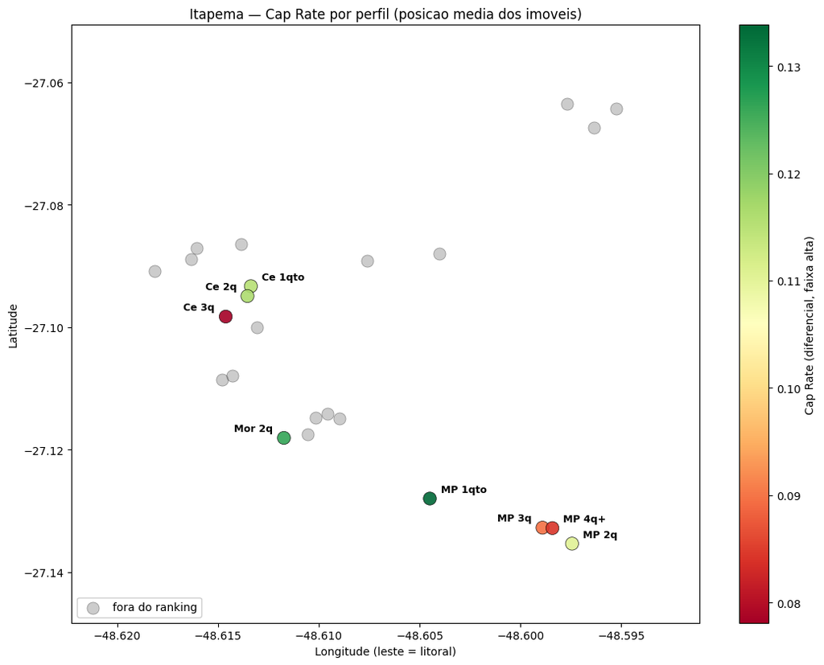

## 11. Considerações finais

### O que eu faria com mais uma semana

Os três pontos que **mudariam a resposta**, não apenas a precisão decimal.

**1. Sair da premissa de ocupação.** Todo Cap Rate aqui depende da faixa assumida de 45–70% — a maior incerteza do trabalho e a única capaz de inverter o ranking de novo. Os dados dão uma pista: o `Price_AV` traz até 3 capturas por par *(imóvel, data de estadia)*, e uma data que some entre capturas provavelmente foi reservada.

**2. Cap Rate líquido, não bruto.** Condomínio (preenchido em 70,1% dos anúncios) e IPTU (67,4%) estão na base e foram tratados como campo indisponível. Com eles, o retorno sai de bruto para líquido em dois terços da amostra — e o payback real cresce.

**3. Regressão para o sinal invertido.** Superhost, rating e nº de reviews aparecem com efeito negativo na seção 8, o que tem mais cara de confundimento com gestão profissional do que de descoberta. Uma regressão com controles diria qual dos dois é.

*Lista completa, com mais tres itens de reforço de confiança, na seção 7 do relatório.*

### Uso da IA

Tratei a IA como parceira de raciocínio, não como executora: trabalhei pelo OpenCode com o DeepSeek e usei o Claude Code numa segunda frente, de revisão e acabamento. O método foi não aceitar a primeira resposta — foi assim que Morretes, descartado como "interior", voltou ao ranking depois da checagem de longitude imóvel a imóvel, e que a reserva instantânea caiu da recomendação ao se revelar proxy de gestão profissional. Onde o dado ficou ambíguo, como no sinal invertido de superhost, registrei a dúvida em vez de inventar explicação. O processo inteiro, iteração por iteração, está em `ai-log/`.